# Human Activity Recognition

Lakin Ducker

Thursday, June 19, 2014

## Load Libraries and Read in Data

```r
# necessary libraries
library(caret)
# set working directory
setwd("D:/R_MachineLearning/Project")

# load data
trainRawData <- read.csv("pml-training.csv",na.strings=c("NA",""))
```

## Exploratory Data Analysis

I conducted exploratory data analysis on the raw training data in order to determine which predictors may have high predictive value and which predictors should be excluded. I made a plot for each variable with the classe variable to look for relationships. It became quickly clear that the variables that mostly had NA values were not valuable predictors.

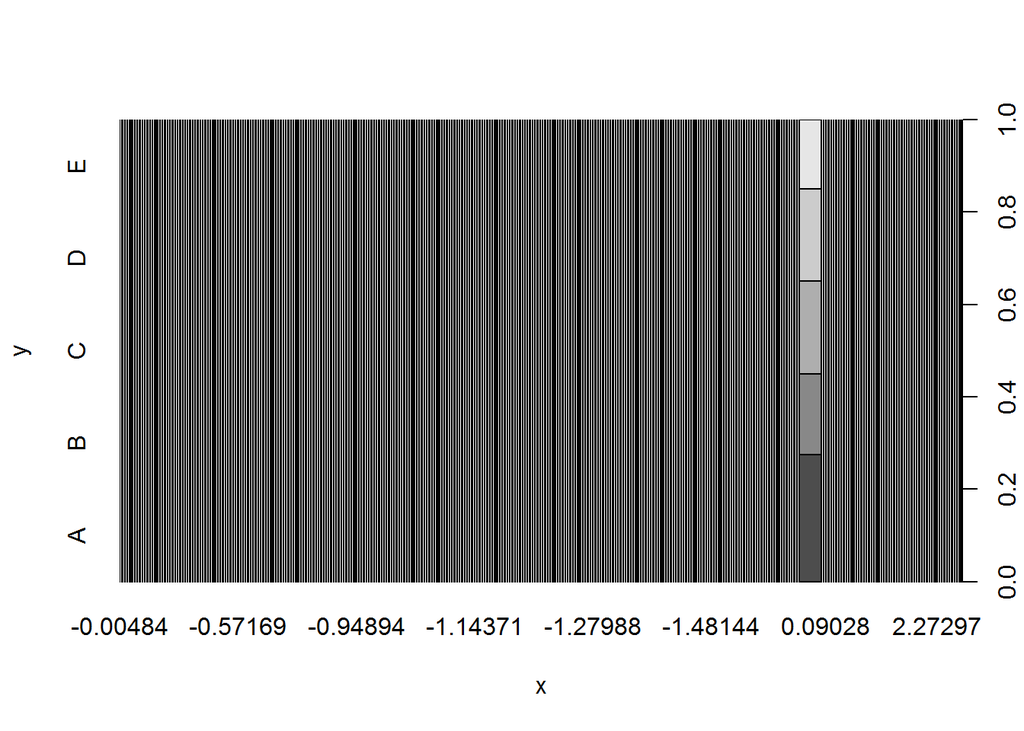

```r
plot(trainRawData$kurtosis_picth_arm, trainRawData$classe)
```

Above is an example of one such variable. The code below removed those variables with NAs.

# Remove NA’s

```r
# remove NA's
NAs <- apply(trainRawData,2,function(x) {sum(is.na(x))})
goodData <- trainRawData[,which(NAs == 0)]
```

## Create Training and Testing Data Subsets

I then created training and testing data subsets, which I named trainData and testData. I needed to use only 30% of the data for the trainData subset because of insufficient RAM on my laptop. However, this appears to have yielded a sufficiently high accuracy. I would have preferred to have used 60% of the data for the trainData subset.

```r
# make trainData set
trainIndex <- createDataPartition(y = goodData$classe, p=0.3,list=FALSE)
trainData <- goodData[trainIndex,]

# make a testData set
testData <- goodData[-trainIndex,]
```

# Remove Non-Useful and Problematic Predictors

I also chose to remove some other predictors that I felt either did not provide predictive value or that could be problematic in overfitting.

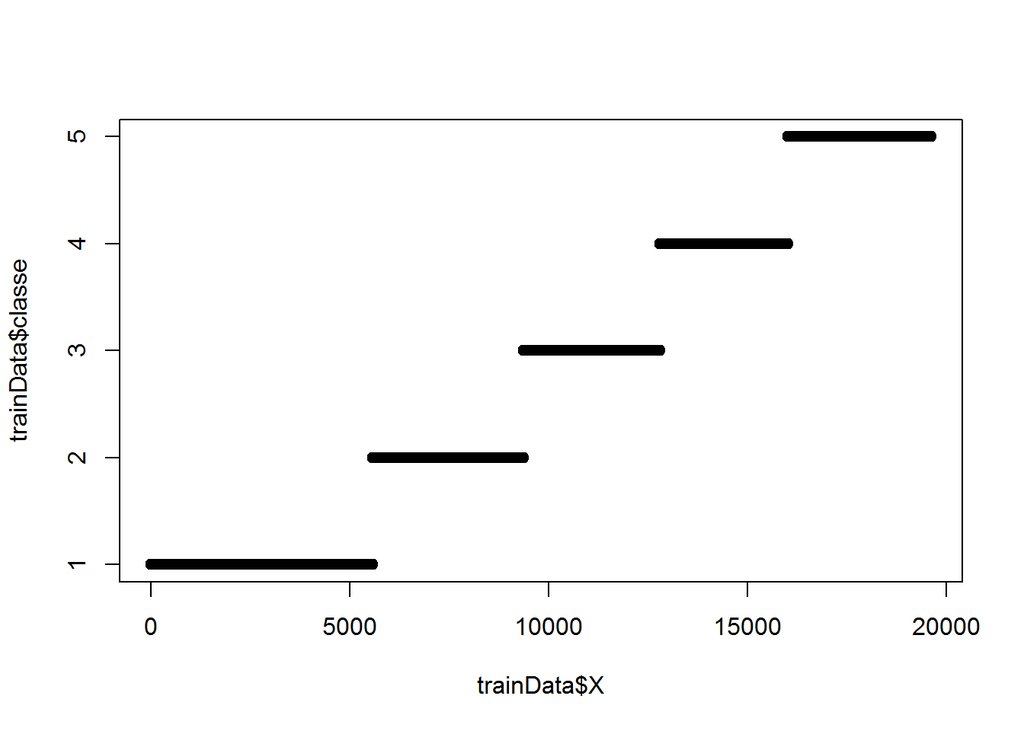

```r
plot(trainData$X, trainData$classe)
```

Above is an example of one such variable. The variable X is the index. While there is clearly a relationship with classe, there was much evidence that it was just showing a temporal pattern. There was additional evidence that this could lead to overfitting and, thus, poor prediction accuracy. The variable “X” and the variables containing “timestamp”, “user_name” and “new_window” were removed.

```r
# remove other predictors with little predictive value
removeIndex <- grep("timestamp|X|user_name|new_window",names(trainData))
trainData <- trainData[,-removeIndex]
```

## Build Machine Learning Algorithm

I decided to use Random Forest as the method in my model because of its ability to find a natural balance between high variance or high bias. There also was no clear underlying model that could be seen simply in exploratory data analysis.

```r
# create model
modFit <- train(trainData$classe ~.,data=trainData,method="rf",prox=TRUE)
modFit
```

[output not shown]

I then built a predictor with the model.

```r
# build predictor
table(predict(modFit,trainData),trainData$classe)
```

```
##
##        A    B    C    D    E
##   A 1674    0    0    0    0
##   B    0 1140    0    0    0
##   C    0    0 1027    0    0
##   D    0    0    0  965    0
##   E    0    0    0    0 1083
```

## Cross Validation and Out of Sample Error

I did cross-validation on the testData subset.

```r
# try on testData
confusionMatrix(predict(modFit,testData),testData$classe)
```

```
## Confusion Matrix and Statistics
##
##           Reference
## Prediction    A    B    C    D    E
##          A 3903   26    0    0    0
##          B    1 2618   14    0    1
##          C    0   11 2380   38    4
##          D    1    2    1 2209    8
##          E    1    0    0    4 2511
##
## Overall Statistics
##
##                Accuracy : 0.992
##                  95% CI : (0.99, 0.993)
##     No Information Rate : 0.284
##     P-Value [Acc > NIR] : <2e-16
##
##                   Kappa : 0.99
##  Mcnemar's Test P-Value : NA
##
## Statistics by Class:
##
##                      Class: A Class: B Class: C Class: D Class: E
## Sensitivity             0.999    0.985    0.994    0.981    0.995
## Specificity             0.997    0.999    0.995    0.999    1.000
## Pos Pred Value          0.993    0.994    0.978    0.995    0.998
## Neg Pred Value          1.000    0.996    0.999    0.996    0.999
## Prevalence              0.284    0.193    0.174    0.164    0.184
## Detection Rate          0.284    0.191    0.173    0.161    0.183
## Detection Prevalence    0.286    0.192    0.177    0.162    0.183
## Balanced Accuracy       0.998    0.992    0.995    0.990    0.997
```

Above are the results of validating the analysis on the testData subset. The Confusion Matrix above shows the expected Accuracy. The expected Out of Sample Error is simply 1 - Accuracy.

## Prediction

At this point I applied my machine learning algorithm to the 20 test cases provided for the project.

```r
# load testing data
testing <- read.csv("pml-testing.csv", header=TRUE)

# Apply on test
testPred <- predict(modFit,testing)
testPred
```

```
##  [1] B A B A A E D B A A B C B A E E A B B B
## Levels: A B C D E
```